# Stup BTRY 6020 Final Project

Rebecca Stup

2025-05-14

# Table of Contents

- Introduction
- Exploratory Data Analysis
- Regression Assumptions Verification
- Assumption Violation Handling
- Variable Selection & Hypothesis Testing
- Feature Impact Analysis
- Conclusion
- References

# Introduction

The dataset used in this analysis is publicly available on Kaggle (Attakorah 2024). It contains ten variables and a million observations. For the sake of computational efficiency, this analysis was performed using a subset of for which the crop in question was corn, which contained 166,824 observations. The dependent variable was the yield in tons per hectare, and all other variables were used as predictors. The goal of this analysis is to predict corn yields based on the various environmental and management factors provided in this dataset.

# Exploratory Data Analysis

The first thing that we will do is familiarize ourselves with the data set, which can be found here: https://www.kaggle.com/datasets/samuelotiattakorah/agriculture-crop-yield

```r
#Load data in
yield_df <- read.csv("C:/Users/rebec/OneDrive/Documents/Class Work/BTRY 6020/crop_yield.csv") #If you would like to follow along, you will need to download the dataset and replace this line of code with its location on your computer.
#Summary statistics of variables
head(yield_df)
```

```
##   Region Soil_Type    Crop Rainfall_mm Temperature_Celsius Fertilizer_Used
## 1   West     Sandy  Cotton    897.0772            27.67697           FALSE
## 2  South      Clay    Rice    992.6733            18.02614            TRUE
## 3  North      Loam  Barley    147.9980            29.79404           FALSE
## 4  North     Sandy Soybean    986.8663            16.64419           FALSE
## 5  South      Silt   Wheat    730.3792            31.62069            TRUE
## 6  South      Silt Soybean    797.4712            37.70497           FALSE
##   Irrigation_Used Weather_Condition Days_to_Harvest Yield_tons_per_hectare
## 1            TRUE            Cloudy             122               6.555816
## 2            TRUE             Rainy             140               8.527341
## 3           FALSE             Sunny             106               1.127443
## 4            TRUE             Rainy             146               6.517573
## 5            TRUE            Cloudy             110               7.248251
## 6            TRUE             Rainy              74               5.898416
```

```r
summary(yield_df)
```

```
##     Region           Soil_Type             Crop            Rainfall_mm
##  Length:1000000     Length:1000000     Length:1000000     Min.   : 100.0
##  Class :character   Class :character   Class :character   1st Qu.: 324.9
##  Mode  :character   Mode  :character   Mode  :character   Median : 550.1
##                                                           Mean   : 550.0
##                                                           3rd Qu.: 774.7
##                                                           Max.   :1000.0
##  Temperature_Celsius Fertilizer_Used Irrigation_Used Weather_Condition
##  Min.   :15.00       Mode :logical   Mode :logical   Length:1000000
##  1st Qu.:21.25       FALSE:500060    FALSE:500509    Class :character
##  Median :27.51       TRUE :499940    TRUE :499491    Mode  :character
##  Mean   :27.50
##  3rd Qu.:33.75
##  Max.   :40.00
##  Days_to_Harvest Yield_tons_per_hectare
##  Min.   : 60.0   Min.   :-1.148
##  1st Qu.: 82.0   1st Qu.: 3.418
##  Median :104.0   Median : 4.652
##  Mean   :104.5   Mean   : 4.649
##  3rd Qu.:127.0   3rd Qu.: 5.879
##  Max.   :149.0   Max.   : 9.963
```

The variables are explained as follows by the creator of the dataset:

- Region: The geographical region where the crop is grown (North, East, South, West).
- Soil_Type: The type of soil in which the crop is planted (Clay, Sandy, Loam, Silt, Peaty, Chalky).
- Crop: The type of crop grown (Wheat, Rice, Maize, Barley, Soybean, Cotton).
- Rainfall_mm: The amount of rainfall received in millimeters during the crop growth period.
- Temperature_Celsius: The average temperature during the crop growth period, measured in degrees Celsius.
- Fertilizer_Used: Indicates whether fertilizer was applied (True = Yes, False = No).
- Irrigation_Used: Indicates whether irrigation was used during the crop growth period (True = Yes, False = No).
- Weather_Condition: The predominant weather condition during the growing season (Sunny, Rainy, Cloudy).
- Days_to_Harvest: The number of days taken for the crop to be harvested after planting.
- Yield_tons_per_hectare: The total crop yield produced, measured in tons per hectare.

This data set is quite large, so we will narrow our focus to a single crop for the sake of computational efficiency. I chose corn, since it is the main crop that I am using in my research at the moment.

```r
#Examine the crop column
table(yield_df$Crop)
```

```
##
##  Barley  Cotton   Maize    Rice Soybean   Wheat
##  166777  166585  166824  166792  166349  166673
```

```r
#Create a subset with jsut corn
corn_df <- yield_df[yield_df$Crop == "Maize", ]
#Summary statistics
summary(corn_df)
```

```
##     Region           Soil_Type             Crop            Rainfall_mm
##  Length:166824      Length:166824      Length:166824      Min.   : 100.0
##  Class :character   Class :character   Class :character   1st Qu.: 323.7
##  Mode  :character   Mode  :character   Mode  :character   Median : 549.7
##                                                           Mean   : 549.2
##                                                           3rd Qu.: 774.0
##                                                           Max.   :1000.0
##  Temperature_Celsius Fertilizer_Used Irrigation_Used Weather_Condition
##  Min.   :15.00       Mode :logical   Mode :logical   Length:166824
##  1st Qu.:21.22       FALSE:83670     FALSE:83419     Class :character
##  Median :27.47       TRUE :83154     TRUE :83405     Mode  :character
##  Mean   :27.48
##  3rd Qu.:33.71
##  Max.   :40.00
##  Days_to_Harvest Yield_tons_per_hectare
##  Min.   : 60.0   Min.   :-0.8752
##  1st Qu.: 82.0   1st Qu.: 3.4099
##  Median :105.0   Median : 4.6426
##  Mean   :104.5   Mean   : 4.6414
##  3rd Qu.:127.0   3rd Qu.: 5.8700
##  Max.   :149.0   Max.   : 9.9530
```

Next, we will visualize individual variables and look for any associations between numeric variables. It initially looks like yield and rainfall may be associated.

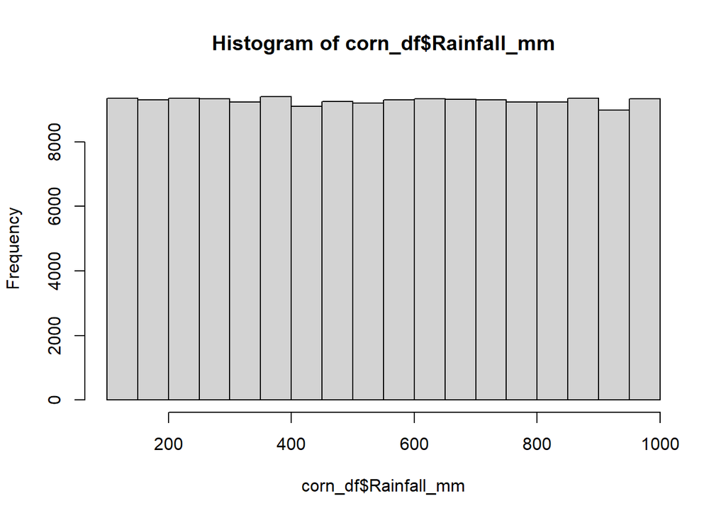

```r
#Visualize numeric variables
hist(corn_df$Rainfall_mm)
```

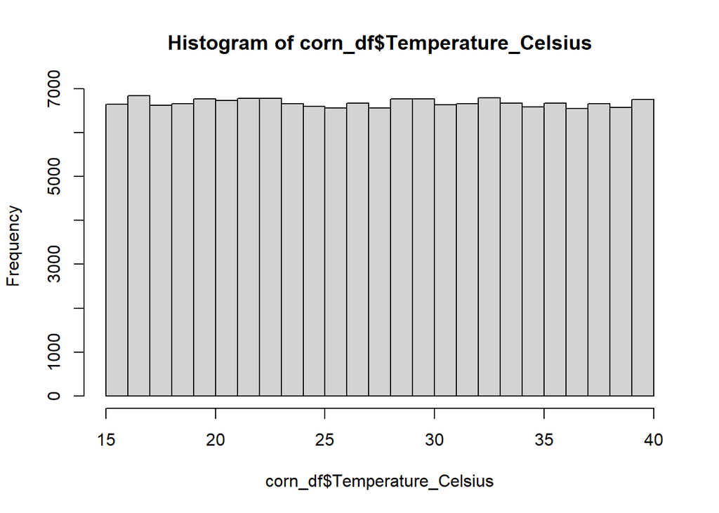

```r
hist(corn_df$Temperature_Celsius)
```

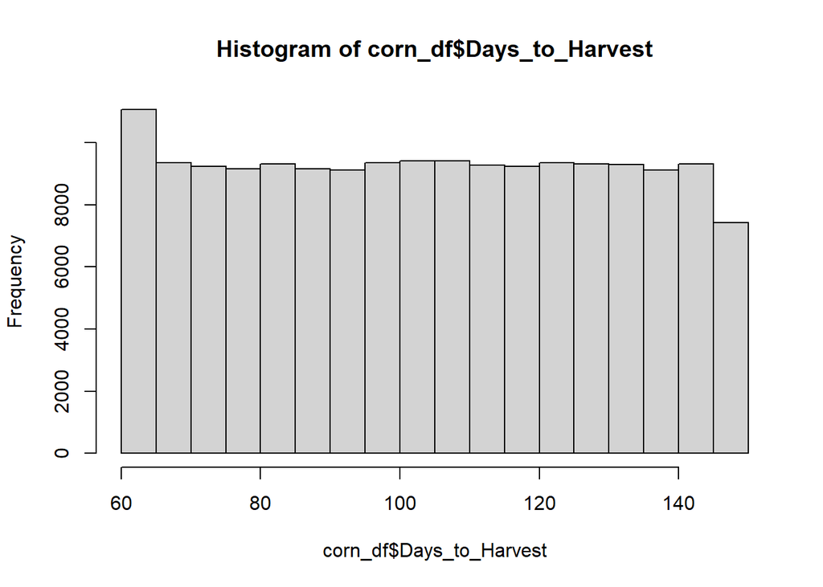

```r
hist(corn_df$Days_to_Harvest)
```

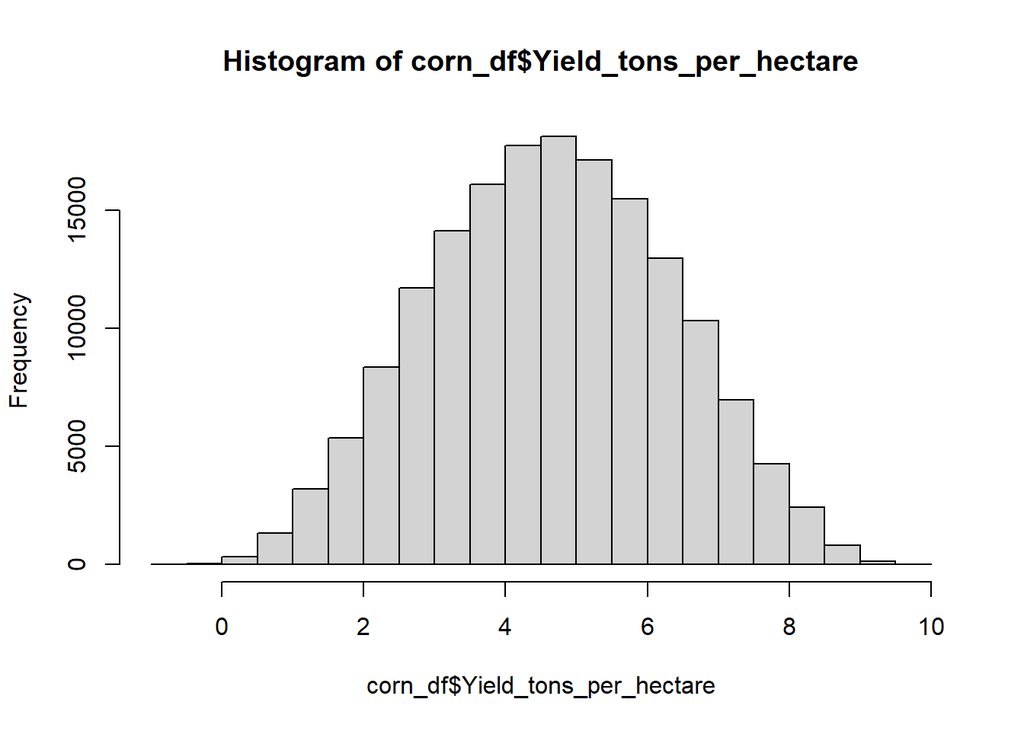

```r
hist(corn_df$Yield_tons_per_hectare)
```

```r
#Tables for categorical variables
table(corn_df$Region)
```

```
##
##  East North South  West
## 41530 41830 41725 41739
```

```r
table(corn_df$Soil_Type)
```

```
##
## Chalky   Clay   Loam  Peaty  Sandy   Silt
##  27885  27631  27908  27819  27788  27793
```

```r
table(corn_df$Fertilizer_Used)
```

```
##
## FALSE  TRUE
## 83670 83154
```

```r
table(corn_df$Irrigation_Used)
```

```
##
## FALSE  TRUE
## 83419 83405
```

```r
table(corn_df$Weather_Condition)
```

```
##
## Cloudy  Rainy  Sunny
##  55323  55663  55838
```

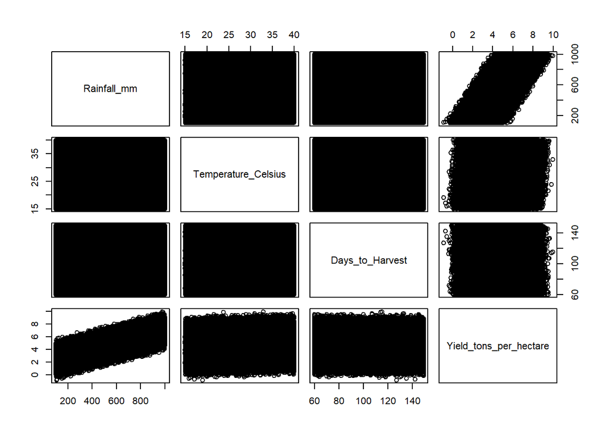

```r
#Check for associations between numeric variables
pairs(corn_df[, -c(1, 2, 3, 6, 7, 8)])
```

Next, we will check for missing data and outliers.

```r
#Check for missing data
anyNA(corn_df)
```

```
## [1] FALSE
```

```r
#Check for outliers
boxplot.stats(corn_df$Rainfall_mm)$out
```

```
## numeric(0)
```

```r
boxplot.stats(corn_df$Temperature_Celsius)$out
```

```
## numeric(0)
```

```r
boxplot.stats(corn_df$Days_to_Harvest)$out
```

```
## integer(0)
```

```r
boxplot.stats(corn_df$Yield_tons_per_hectare)$out
```

```
##  [1] -0.5594590 -0.3350481 -0.3496012 -0.6998194  9.9529827  9.6539375
##  [7] -0.4057636 -0.8751928 -0.3203194  9.6178168  9.8262854
```

There is no missing data, and only a few outliers. For now, I am choosing to leave the outliers in. This dataset is already very clean, but I am going to set all of the qualitative predictor variables as factors to ensure my code works properly.

```r
corn_df$Region<-as.factor(corn_df$Region)
corn_df$Soil_Type<-as.factor(corn_df$Soil_Type)
corn_df$Crop<-as.factor(corn_df$Crop)
corn_df$Weather_Condition<-as.factor(corn_df$Weather_Condition)
corn_df$Fertilizer_Used<-as.factor(corn_df$Fertilizer_Used)
corn_df$Irrigation_Used<-as.factor(corn_df$Irrigation_Used)
```

# Regression Assumptions Verification

First, let’s fit a model will all of the possible covariates.

```r
corn_mod <- lm(Yield_tons_per_hectare~ Rainfall_mm + Temperature_Celsius + Days_to_Harvest + Region + Soil_Type + Fertilizer_Used + Irrigation_Used, data=corn_df)
summary(corn_mod)
```

```
##
## Call:
## lm(formula = Yield_tons_per_hectare ~ Rainfall_mm + Temperature_Celsius +
##     Days_to_Harvest + Region + Soil_Type + Fertilizer_Used +
##     Irrigation_Used, data = corn_df)
##
## Residuals:
##      Min       1Q   Median       3Q      Max
## -2.35191 -0.33762 -0.00043  0.33860  2.04239
##
## Coefficients:
##                       Estimate Std. Error  t value Pr(>|t|)
## (Intercept)          1.543e-02  8.326e-03    1.853  0.06382 .
## Rainfall_mm          4.996e-03  4.710e-06 1060.747  < 2e-16 ***
## Temperature_Celsius  1.987e-02  1.696e-04  117.136  < 2e-16 ***
## Days_to_Harvest     -2.099e-05  4.717e-05   -0.445  0.65634
## RegionNorth         -2.166e-03  3.464e-03   -0.625  0.53168
## RegionSouth         -6.613e-03  3.466e-03   -1.908  0.05636 .
## RegionWest          -4.852e-03  3.465e-03   -1.400  0.16146
## Soil_TypeClay       -1.093e-03  4.244e-03   -0.258  0.79679
## Soil_TypeLoam       -5.736e-03  4.234e-03   -1.355  0.17542
## Soil_TypePeaty      -7.520e-03  4.237e-03   -1.775  0.07592 .
## Soil_TypeSandy      -4.386e-03  4.238e-03   -1.035  0.30075
## Soil_TypeSilt       -1.227e-02  4.238e-03   -2.896  0.00379 **
## Fertilizer_UsedTRUE  1.498e+00  2.448e-03  611.847  < 2e-16 ***
## Irrigation_UsedTRUE  1.201e+00  2.448e-03  490.364  < 2e-16 ***
## ---
## Signif. codes:  0 '***' 0.001 '**' 0.01 '*' 0.05 '.' 0.1 ' ' 1
##
## Residual standard error: 0.5 on 166810 degrees of freedom
## Multiple R-squared:  0.9131, Adjusted R-squared:  0.9131
## F-statistic: 1.348e+05 on 13 and 166810 DF,  p-value: < 2.2e-16
```

Next, we will plot the residuals to check for linearity and homoscedasticity, as well as the Q-Q plot to check for normality.

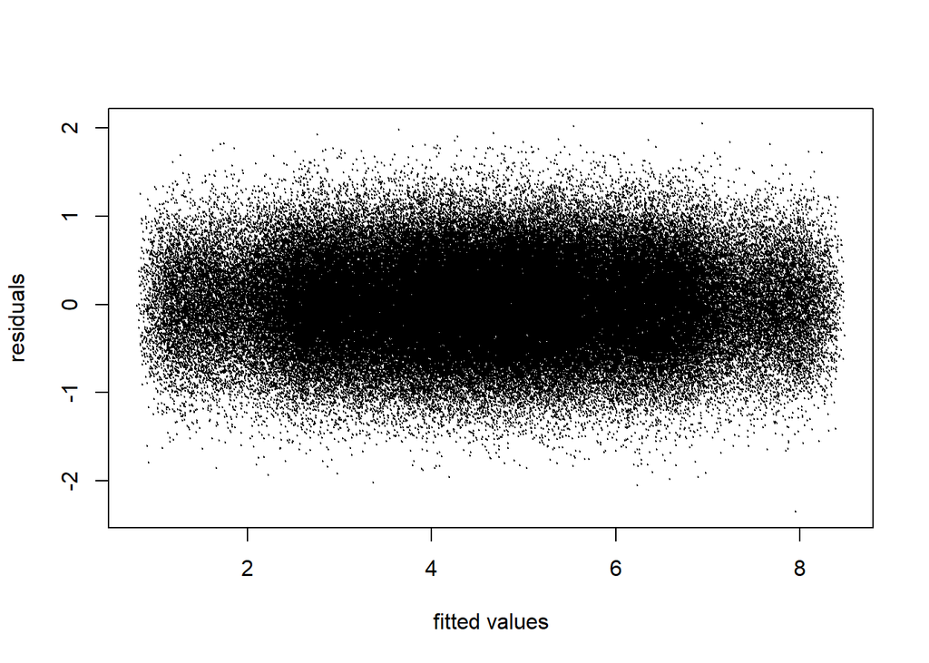

```r
plot(corn_mod$fitted.values, corn_mod$residuals, pch = 19, cex = .1,
     xlab = "fitted values", ylab = "residuals")
```

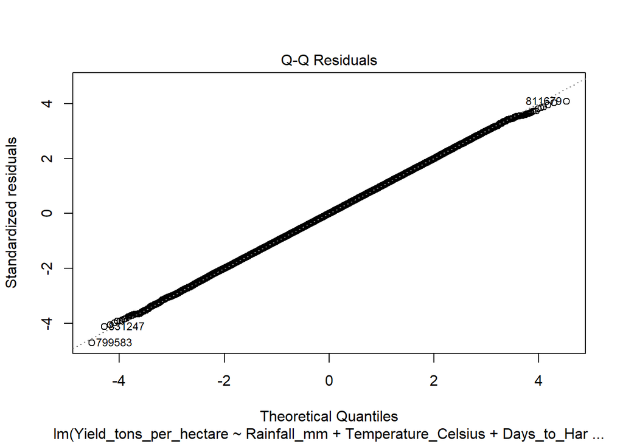

```r
plot(corn_mod, which = 2)
```

The plot of the residuals has no clear pattern and is centered around zero, meaning that the assumptions of linearity and homoscedasticity are likely met. The Q-Q plot is a straight line, so we can say that our data is normally distributed.

We will use a Durbin-Watson test to check that the errors are independent.

```r
library(lmtest)
dwtest(corn_mod)
```

```
##
##  Durbin-Watson test
##
## data:  corn_mod
## DW = 1.9983, p-value = 0.3662
## alternative hypothesis: true autocorrelation is greater than 0
```

Based on these results, we cannot reject the null hypothesis that there is no autocorrelation in this data.

To test for multicollinearity, we will use the Variance Inflation Factor.

```r
library(car)
vif(corn_mod)
```

```
##                         GVIF Df GVIF^(1/(2*Df))
## Rainfall_mm         1.000081  1        1.000040
## Temperature_Celsius 1.000078  1        1.000039
## Days_to_Harvest     1.000097  1        1.000049
## Region              1.000130  3        1.000022
## Soil_Type           1.000344  5        1.000034
## Fertilizer_Used     1.000051  1        1.000025
## Irrigation_Used     1.000054  1        1.000027
```

All of the values given are close to 1, so this assumption is not violated.

# Assumption Violation Handling

Because all of the key assumptions of multiple linear regression were met by this dataset, no transformations were applied. For the purposes of this assignment, I will briefly discuss what steps I could have taken if any of the assumptions had been violated.

- If the assumptions of linearity, homoscedasticity, or normality had been violated, the appropriate response would be to transform the data (typically, this is a log transformation or a square root transformation) and compare the plots of the potential transformations.
- If the assumption of independence of errors was violated, an appropriate response would be to use a fixed effects model.
- If the assumption that multicollinearity is low was violated, an appropriate response would be to remove a predictor.

# Variable Selection & Hypothesis Testing

Now that we have confirmed that our model meets the assumptions of multiple linear regression, we can use model selection algorithms to determine which set of covariates to include for optimal predictive power. We will compare the results of two different procedures, backwards stepwise selection and forwards stepwise selection and choose the model with the best fit (in this case, this will be the model with the lower BIC).

```r
#Backward stepwise selection with BIC
backward_bic<-step(object=corn_mod,direction="backward", scope=formula(corn_mod),trace=T,k=log(nrow(corn_df)))
```

```
## Start:  AIC=-231124.6
## Yield_tons_per_hectare ~ Rainfall_mm + Temperature_Celsius +
##     Days_to_Harvest + Region + Soil_Type + Fertilizer_Used +
##     Irrigation_Used
##
##                       Df Sum of Sq    RSS     AIC
## - Soil_Type            5         3  41702 -231174
## - Region               3         1  41701 -231156
## - Days_to_Harvest      1         0  41700 -231136
## <none>                              41700 -231125
## - Temperature_Celsius  1      3430  45130 -217950
## - Irrigation_Used      1     60110 101809  -82227
## - Fertilizer_Used      1     93583 135282  -34806
## - Rainfall_mm          1    281276 322976  110367
##
## Step:  AIC=-231173.6
## Yield_tons_per_hectare ~ Rainfall_mm + Temperature_Celsius +
##     Days_to_Harvest + Region + Fertilizer_Used + Irrigation_Used
##
##                       Df Sum of Sq    RSS     AIC
## - Region               3         1  41703 -231205
## - Days_to_Harvest      1         0  41702 -231185
## <none>                              41702 -231174
## - Temperature_Celsius  1      3429  45132 -218002
## - Irrigation_Used      1     60110 101813  -82282
## - Fertilizer_Used      1     93586 135288  -34859
## - Rainfall_mm          1    281295 322997  110318
##
## Step:  AIC=-231205.5
## Yield_tons_per_hectare ~ Rainfall_mm + Temperature_Celsius +
##     Days_to_Harvest + Fertilizer_Used + Irrigation_Used
##
##                       Df Sum of Sq    RSS     AIC
## - Days_to_Harvest      1         0  41703 -231217
## <none>                              41703 -231205
## - Temperature_Celsius  1      3429  45133 -218034
## - Irrigation_Used      1     60110 101814  -82317
## - Fertilizer_Used      1     93586 135289  -34893
## - Rainfall_mm          1    281295 322999  110282
##
## Step:  AIC=-231217.3
## Yield_tons_per_hectare ~ Rainfall_mm + Temperature_Celsius +
##     Fertilizer_Used + Irrigation_Used
##
##                       Df Sum of Sq    RSS     AIC
## <none>                              41703 -231217
## - Temperature_Celsius  1      3429  45133 -218046
## - Irrigation_Used      1     60112 101815  -82327
## - Fertilizer_Used      1     93587 135291  -34904
## - Rainfall_mm          1    281297 323000  110271
```

```r
#Forward stepwise selection with BIC
null_mod <- lm(Yield_tons_per_hectare~ 1, data=corn_df)
forward_bic<-step(object=null_mod,direction="forward", scope=formula(corn_mod),trace=T,k=log(nrow(corn_df)))
```

```
## Start:  AIC=176272.7
## Yield_tons_per_hectare ~ 1
##
##                       Df Sum of Sq    RSS    AIC
## + Rainfall_mm          1    280626 199239  29646
## + Fertilizer_Used      1     93056 386810 140322
## + Irrigation_Used      1     60684 419181 153730
## + Temperature_Celsius  1      3532 476334 175052
## <none>                             479866 176273
## + Days_to_Harvest      1        11 479855 176281
## + Region               3         2 479863 176308
## + Soil_Type            5        33 479833 176321
##
## Step:  AIC=29646.41
## Yield_tons_per_hectare ~ Rainfall_mm
##
##                       Df Sum of Sq    RSS    AIC
## + Fertilizer_Used      1     93968 105271 -76770
## + Irrigation_Used      1     60508 138731 -30726
## + Temperature_Celsius  1      3467 195772  26730
## <none>                             199239  29646
## + Days_to_Harvest      1         5 199234  29655
## + Region               3         1 199238  29682
## + Soil_Type            5         8 199231  29699
##
## Step:  AIC=-76770.13
## Yield_tons_per_hectare ~ Rainfall_mm + Fertilizer_Used
##
##                       Df Sum of Sq    RSS     AIC
## + Irrigation_Used      1     60138  45133 -218046
## + Temperature_Celsius  1      3456 101815  -82327
## <none>                             105271  -76770
## + Days_to_Harvest      1         2 105269  -76761
## + Region               3         1 105270  -76735
## + Soil_Type            5         4 105267  -76716
##
## Step:  AIC=-218045.6
## Yield_tons_per_hectare ~ Rainfall_mm + Fertilizer_Used + Irrigation_Used
##
##                       Df Sum of Sq   RSS     AIC
## + Temperature_Celsius  1    3429.4 41703 -231217
## <none>                             45133 -218046
## + Days_to_Harvest      1       0.2 45133 -218034
## + Region               3       0.9 45132 -218013
## + Soil_Type            5       2.2 45131 -217994
##
## Step:  AIC=-231217.3
## Yield_tons_per_hectare ~ Rainfall_mm + Fertilizer_Used + Irrigation_Used +
##     Temperature_Celsius
##
##                   Df Sum of Sq   RSS     AIC
## <none>                         41703 -231217
## + Days_to_Harvest  1   0.05246 41703 -231205
## + Region           3   1.04479 41702 -231185
## + Soil_Type        5   2.77172 41701 -231168
```

```r
#Summary of results
summary(backward_bic)
```

```
##
## Call:
## lm(formula = Yield_tons_per_hectare ~ Rainfall_mm + Temperature_Celsius +
##     Fertilizer_Used + Irrigation_Used, data = corn_df)
##
## Residuals:
##      Min       1Q   Median       3Q      Max
## -2.34992 -0.33783 -0.00082  0.33868  2.03630
##
## Coefficients:
##                      Estimate Std. Error  t value Pr(>|t|)
## (Intercept)         4.718e-03  5.733e-03    0.823    0.411
## Rainfall_mm         4.996e-03  4.710e-06 1060.765   <2e-16 ***
## Temperature_Celsius 1.987e-02  1.696e-04  117.125   <2e-16 ***
## Fertilizer_UsedTRUE 1.498e+00  2.448e-03  611.850   <2e-16 ***
## Irrigation_UsedTRUE 1.201e+00  2.448e-03  490.361   <2e-16 ***
## ---
## Signif. codes:  0 '***' 0.001 '**' 0.01 '*' 0.05 '.' 0.1 ' ' 1
##
## Residual standard error: 0.5 on 166819 degrees of freedom
## Multiple R-squared:  0.9131, Adjusted R-squared:  0.9131
## F-statistic: 4.382e+05 on 4 and 166819 DF,  p-value: < 2.2e-16
```

```r
summary(forward_bic)
```

```
##
## Call:
## lm(formula = Yield_tons_per_hectare ~ Rainfall_mm + Fertilizer_Used +
##     Irrigation_Used + Temperature_Celsius, data = corn_df)
##
## Residuals:
##      Min       1Q   Median       3Q      Max
## -2.34992 -0.33783 -0.00082  0.33868  2.03630
##
## Coefficients:
##                      Estimate Std. Error  t value Pr(>|t|)
## (Intercept)         4.718e-03  5.733e-03    0.823    0.411
## Rainfall_mm         4.996e-03  4.710e-06 1060.765   <2e-16 ***
## Fertilizer_UsedTRUE 1.498e+00  2.448e-03  611.850   <2e-16 ***
## Irrigation_UsedTRUE 1.201e+00  2.448e-03  490.361   <2e-16 ***
## Temperature_Celsius 1.987e-02  1.696e-04  117.125   <2e-16 ***
## ---
## Signif. codes:  0 '***' 0.001 '**' 0.01 '*' 0.05 '.' 0.1 ' ' 1
##
## Residual standard error: 0.5 on 166819 degrees of freedom
## Multiple R-squared:  0.9131, Adjusted R-squared:  0.9131
## F-statistic: 4.382e+05 on 4 and 166819 DF,  p-value: < 2.2e-16
```

Both procedures selected rainfall, temperature, the use of fertilization, and the use of irrigation as predictor variables for the true model. Both procedures also resulted the in same value for the BIC (-231217). Since the results were the same, we don’t have to choose between the models.

Now, let’s fit the new model and perform hypothesis tests on the predictor variables.

```r
#Fit the new model
corn_mod2 <- lm(Yield_tons_per_hectare ~ Rainfall_mm + Fertilizer_Used + Irrigation_Used + Temperature_Celsius, data = corn_df)
#t-tests for individual variables are automatically included in model summaries in R, so let's look at them now
summary(corn_mod2)
```

```
##
## Call:
## lm(formula = Yield_tons_per_hectare ~ Rainfall_mm + Fertilizer_Used +
##     Irrigation_Used + Temperature_Celsius, data = corn_df)
##
## Residuals:
##      Min       1Q   Median       3Q      Max
## -2.34992 -0.33783 -0.00082  0.33868  2.03630
##
## Coefficients:
##                      Estimate Std. Error  t value Pr(>|t|)
## (Intercept)         4.718e-03  5.733e-03    0.823    0.411
## Rainfall_mm         4.996e-03  4.710e-06 1060.765   <2e-16 ***
## Fertilizer_UsedTRUE 1.498e+00  2.448e-03  611.850   <2e-16 ***
## Irrigation_UsedTRUE 1.201e+00  2.448e-03  490.361   <2e-16 ***
## Temperature_Celsius 1.987e-02  1.696e-04  117.125   <2e-16 ***
## ---
## Signif. codes:  0 '***' 0.001 '**' 0.01 '*' 0.05 '.' 0.1 ' ' 1
##
## Residual standard error: 0.5 on 166819 degrees of freedom
## Multiple R-squared:  0.9131, Adjusted R-squared:  0.9131
## F-statistic: 4.382e+05 on 4 and 166819 DF,  p-value: < 2.2e-16
```

```r
#We can use the anova function to run an F-test on the model
anova(corn_mod2)
```

```
## Analysis of Variance Table
##
## Response: Yield_tons_per_hectare
##                         Df Sum Sq Mean Sq F value    Pr(>F)
## Rainfall_mm              1 280626  280626 1122541 < 2.2e-16 ***
## Fertilizer_Used          1  93968   93968  375885 < 2.2e-16 ***
## Irrigation_Used          1  60138   60138  240560 < 2.2e-16 ***
## Temperature_Celsius      1   3429    3429   13718 < 2.2e-16 ***
## Residuals           166819  41703       0
## ---
## Signif. codes:  0 '***' 0.001 '**' 0.01 '*' 0.05 '.' 0.1 ' ' 1
```

All of the variables are highly significant in this model, both jointly (from the F-test) and on their on (from the t-tests). Because our goal is to fit a predictive model, we should focus more on validating the model than on hypothesis testing for individual coefficients. Because of this, our next step will be to assess model performance. Some metrics, like the R² (0.9131) and the adjusted R² (0.9131), were also given to us in the summary of our model. These are fairly high (R² is on a scale from 0 to 1), so they indicate that the model fits the data well. However, R² does not penalize complexity, which can lead to overfitting. To further assess the model, we will calculate the RMSE and validate the model using K-fold cross validation.

```r
#RMSE is the square root of the mean of the error (actual-fitted) squared
rmse <- sqrt(mean((corn_df$Yield_tons_per_hectare-corn_mod2$fitted.values)^2))
rmse # 0.4999846
```

```
## [1] 0.4999846
```

```r
#Compare with RMSE of full model
rmse2 <- sqrt(mean((corn_df$Yield_tons_per_hectare-corn_mod$fitted.values)^2))
rmse2 # 0.4999846
```

```
## [1] 0.4999613
```

```r
#K-fold cross validation divided into 10 folds
library("boot")
err_cv <- cv.glm(corn_df, glm(Yield_tons_per_hectare~ Rainfall_mm + Fertilizer_Used + Irrigation_Used + Temperature_Celsius, data = corn_df), K = 10)
#Get the value of the total MSE
err_cv$delta[1]
```

```
## [1] 0.2499979
```

```r
#Compare with full model
err_cv2 <- cv.glm(corn_df, glm(Yield_tons_per_hectare~ Rainfall_mm + Fertilizer_Used + Irrigation_Used + Temperature_Celsius + Days_to_Harvest + Region + Soil_Type, data = corn_df), K = 10)
err_cv2$delta[1]
```

```
## [1] 0.2500052
```

For both the RMSE and the total MSE obtained from cross-validation, a smaller result means that the model has more predictive power. In this case, the models are very comparable. The model that we decided was optimal based on the selection procedures performs very slightly better in the cross-validation, and is simpler, so we will continue to use that one.

# Feature Impact Analysis

Finally, it’s time to interpret the model! Let’s take a look at the coefficients and confidence intervals:

```r
#Coefficients from the model
coef(corn_mod2)
```

```
##         (Intercept)         Rainfall_mm Fertilizer_UsedTRUE Irrigation_UsedTRUE
##         0.004717775         0.004996235         1.498006914         1.200552898
## Temperature_Celsius
##         0.019865280
```

```r
#95% confidence intervals
coefci(corn_mod2, level = .95)
```

```
##                            2.5 %      97.5 %
## (Intercept)         -0.006518219 0.015953769
## Rainfall_mm          0.004987003 0.005005466
## Fertilizer_UsedTRUE  1.493208251 1.502805577
## Irrigation_UsedTRUE  1.195754274 1.205351522
## Temperature_Celsius  0.019532852 0.020197707
```

# Conclusion

From a practical standpoint, the results of this analysis indicate that the most relevant factors when it comes to predicting yield are the total rainfall and average temperature in an area, as well as whether or not the field was irrigated or fertilized. All of these factors are positively correlated with yield. However, it would be very strange for a farmer not to fertilize their fields, so it can be safely assumed that the overwhelming majority of data points for this factor would be “true” for the majority of datasets. Also, it would likely be more useful to look at fertilization and irrigation rates than simply whether or not these practices were implemented. Unlike rainfall and average temperature, these factors are within farmers’ control, making them especially important. It is not possible with this particular dataset, but a model that predicts increases in crop yield based off of application rates would be the most useful from a management perspective. This would be especially useful if the model was capable of determining the rate at which the increase in yield begins to plateau, so that farmers could minimize costs by not applying extraneous fertilizer.

# References

Attakorah, S.O. (2024, September). Agriculture Crop Yield, Version 1. Retrieved May 13, 2025 from https://www.kaggle.com/datasets/samuelotiattakorah/agriculture-crop-yield.